# Vitamin genes

Set up

```r
rm(list=ls()) #clear workspace

library(tidyverse)
library(reshape2)
library(ggplot2)
library(tidytree)
library(dplyr)
library(ggtree)
library(ggtreeExtra)
library(ggnewscale)
```

##Open files load results of eggnog workflow

```r
genes_list <- read.csv("data/vitamin-ECs-Jan2023.csv")

sensitive <- read.csv("data/metadata_sensitive_strains.csv")

phylo <- read.csv("data/taxonomy-151strains.csv", row.names = 1)

tree <-read.tree("data/prunedGenomes.tree")

tree <- drop.tip(tree, "13B01") ##removing one missing genome, 13B01

phylo <- phylo[match(tree$tip.label, phylo$taxa),] ##now match the tax order to the tree, as well as drop the missing taxa temporarily
```

Melt auxotrophy metadata

```r
sens.melt <- melt(sensitive,measure.vars = c("auxo_1", "auxo_2", "auxo_3", "auxo_4"))

sens.melt <-sens.melt[!sens.melt$value=="", ]
```

##Fig 2a- Rhodobacterales B1 genes

Load gene table

```r
eggnog <- readRDS("data/vitamin-annotations-eggnog-genetable-Aug2023.RDS")
```

For B1:

```r
vit <- "Thiamine"
vit_B <- "B1"
steps <- c("Thiazole","Thiazole_eukaryotic", "Pyrimidine","Coupling")
```

Subset to Rhodobacterales

```r
ordername <- "Rhodobacterales"

subset <- subset(phylo, order==ordername) #select a specific order of interest
```

Visualize B1 genes

```r
genes_subset <- t(eggnog[match(subset$taxa,rownames(eggnog)),]) #subset the gene matrix to only Rhodobacterales

genes_subset[genes_subset<1] <-NA ##convert 0 to NA

genes_list_subset <- genes_list[match(rownames(genes_subset), genes_list$Abbreviation),]

genes_subset <- as.data.frame(cbind("Vitamin"=genes_list_subset$Vitamin, "Gene"=genes_list_subset$Abbreviation, "Function"=genes_list_subset$Function, "EC"=genes_list_subset$EC, genes_subset)) ##add in some metadata

genes_melt <-melt(genes_subset, na.rm=T, id.vars=c("Vitamin","EC","Function", "Gene"))


genes_vit <- subset(genes_subset, Vitamin==vit)

##Create a categorical matrix
genes_vit.m <- melt(genes_vit, id.vars=c("Vitamin", "Gene", "Function", "EC"))
genes_vit.m <- na.omit(genes_vit.m)

genes_vit.cat <- dcast(genes_vit.m, variable ~ Gene, value.var= "Function" )
rownames(genes_vit.cat) <- genes_vit.cat[,1]
genes_vit.cat <- genes_vit.cat[,-1]

##Match the order to the function using the steps vector  defined above
genes_vit <- genes_vit[genes_vit$Gene %in% colnames(genes_vit.cat),] ##first match genes relevant for this vitamin

genes_vit$Function <- factor(genes_vit$Function, levels=steps)

genes_vit <- genes_vit[order(genes_vit$Function),] ##order metadata by levels
genes_vit.cat <- genes_vit.cat[,genes_vit$Gene] ##order columns in the matrix in the same order



##Create a corresponding list of B1 sensitive strains
sensitive_subset <- sens.melt[sens.melt$strains %in% subset$taxa,]
sensitive_subset <- subset(sensitive_subset, value==vit_B)

#Make tree for this subset of taxa
pruned.tree2 <-drop.tip(tree, setdiff(tree$tip.label, subset$taxa))
##make groupings based on list of B1 auxo and non auxo
pruned.tree2 <- groupOTU(pruned.tree2, list(auxotrophy = sensitive_subset$strains))
```

make the plot

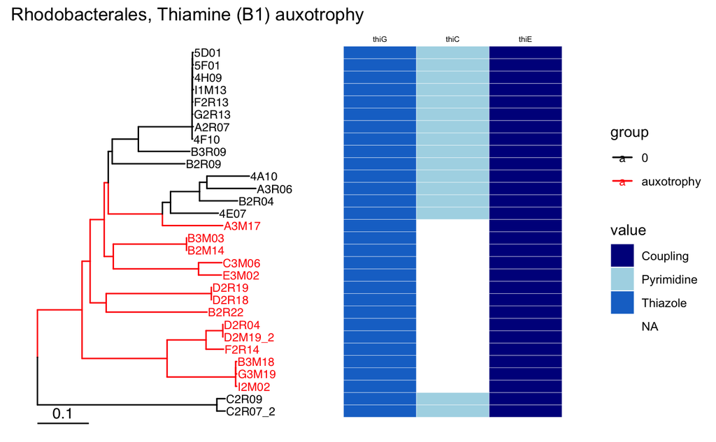

```r
p <- ggtree(pruned.tree2, aes(color=group)) + geom_tiplab(aes(color=group),size=3)+
     scale_color_manual(values = c("black", "red"))+
    geom_treescale(x=0, y=0, width=0.1)+
  ggtitle(paste0(ordername,", ",vit," (",vit_B, ") auxotrophy"))

p1 <- p+ new_scale_fill()

#subset the matrix to focus on key genes in B1 pathway
keygenes_vit.cat <- genes_vit.cat[,colnames(genes_vit.cat) %in% c("thiC","thiG","thiE")]

gheatmap(p1, keygenes_vit.cat, offset=0.1, width=1, font.size=2,
        colnames_angle=0, hjust=0.5,colnames_position="top", legend_title="Function", colnames_offset_y = 0.1)+
  scale_fill_manual(values=c("darkblue","lightblue","dodgerblue3"),na.value="white")
```

##Predict auxotrophies based on genomes

load files

```r
eggnog <- readRDS("data/vitamin-annotations-eggnog-genetable-Aug2023.RDS")

##B12 annotations are based on expanded list of ECs
eggnog_B12 <- readRDS("data/vitamin-annotations-eggnog-EC-B12-gene-table-Sept2023.RDS")
```

Find vitamin related genes

```r
genes_subset <- t(eggnog) #subset the gene matrix to only those taxa

#genes_subset[genes_subset<1] <-NA ##convert 0 to NA

genes_list_subset <- genes_list[match(rownames(genes_subset), genes_list$Abbreviation),]

genes_subset <- as.data.frame(cbind("Vitamin"=genes_list_subset$Vitamin, "Gene"=genes_list_subset$Abbreviation, "Function"=genes_list_subset$Function, "EC"=genes_list_subset$EC, genes_subset)) ##add in some metadata

genes_melt <-melt(genes_subset, na.rm=T, id.vars=c("Vitamin","EC","Function", "Gene"))
```

List of vitamins and their corresponding B numbers and steps

```r
vitamins <- list(
  list(name = "Thiamine", code = "B1", steps = c("Thiazole", "Thiazole_eukaryotic", "Pyrimidine", "Coupling")),
  list(name = "Niacin", code = "B3", steps = c("Aspartate", "Kynurenine", "Nicotinamide", "NAD")),
  list(name = "Biotin", code = "B7", steps = c("Pimelate", "Bicyclic_rings")),
  list(name = "Folate", code = "B9", steps = c("PABA", "Pterin", "Condensation", "Reductase")),
  list(name = "Cobalamin", code = "B12", steps = c("Corrin", "Ligands", "Methionine"))
)
```

Find vitamin genes in eggnog annotations

```r
# Create a list to store the resulting dataframes
result_dataframes <- list()

# Loop through the list of vitamins
for (vitamin in vitamins) {
  vit <- vitamin$name
  vit_B <- vitamin$code
  steps <- vitamin$steps

  # Subset the data for the current vitamin
  genes_vit <- subset(genes_subset, Vitamin == vit)
  rownames(genes_vit) <- genes_vit$Gene
  genes_vit <- t(genes_vit[, -c(1:4)])
  mode(genes_vit) <- "numeric"
  genes_vit[genes_vit > 1] <- 1
  genes_vit <- as.data.frame(genes_vit)

  # Store the dataframe in the result list
  result_dataframes[[vit_B]] <- genes_vit

  rm(vitamin, steps, vit, vit_B)
}

# result_dataframes now contains five separate dataframes (genesB1, genesB3, genesB7, genesB9, genesB12)

eggnog_B12[eggnog_B12 > 1] <- 1

result_dataframes$B12 <- eggnog_B12
```

Make the dataframe for the analysis

```r
##Make a list of the experimental results for auxotrophies for each vitamin
##Insert 1s for prototrophs and 0s for auxotrophs.
panel <- dcast(sens.melt, strains ~ value, fill=1)

vits <-panel %>%
  select(B1, B3, B7, B9, B12) %>%
  mutate_all(as.numeric)
panel <- cbind(taxa =panel$strains, vits)

panel[is.na(panel)] = 0

##now add in the prototrophs

phylo_proto <- phylo[!phylo$taxa %in% panel$taxa,]

proto <- cbind(taxa=phylo_proto$taxa, B1= 1, B3 =1, B7= 1, B9=1, B12=1)

predictions <- rbind(panel, proto)
predictions$B1 <- as.numeric(predictions$B1)
predictions$B3 <- as.numeric(predictions$B3)
predictions$B7 <- as.numeric(predictions$B7)
predictions$B9 <- as.numeric(predictions$B9)
predictions$B12 <- as.numeric(predictions$B12)
```

figure out the filtering the lists of genes here are based on: Systematic genome assessment of B-vitamin biosynthesis suggests co-operation among gut microbes

Predict B1 prototrophs Condition is thiC + [thiG or thi4] + [thiE or thiN] Reference: “Prevalent reliance of bacterioplankton on exogenous vitamin B1 and precursor availability”, Paerl et al, PNAS, 2018 https://doi.org/10.1073/pnas.1806425115

```r
#predict prototrophs
protoB1 <- result_dataframes$B1 %>% filter(thiC == 1, thiG==1, (thiE == 1 | thiE2 == 1|thiN == 1))


B1_list <- cbind(rownames(protoB1), "1")
colnames(B1_list) <- c("taxa","predictedB1")

predictions <- merge(predictions, B1_list, by="taxa", all=T)
```

Predict B3 prototrophs

Reference: “Systematic genome assessment of B-vitamin biosynthesis suggests co-operation among gut microbes”, Magnusdottir et al, Front. Genet., 2015

Genes: ASPOX + QSYN + QAPRT + NaMNAT + NADS, which is equivalent to [[(nadX or nadB) + nadA] + nadC + nadD + nadE

kmo gene added as representative gene from kynurenine pathway for quinolinate biosynthesis via tryptophan, present in Flavobacteriales. Reference: “NAD biosynthesis evolution in bacteria: lateral gene transfer of kynurenine pathway in Xanthomonadales and Flavobacteriales,” Lima et al, Mol. Biol. Evol., 2009.

Final condition: [[(nadX or nadB) + nadA] or [kmo]] + nadC + nadD + nadE

```r
protoB3 <- result_dataframes$B3 %>% filter(nadC ==1 & nadD==1 & nadE ==1) %>% filter(((nadB == 1 | nadX==1) & nadA ==1) | kmo == 1)

B3_list <- cbind(rownames(protoB3), "1")
colnames(B3_list) <- c("taxa","predictedB3")

predictions <- merge(predictions, B3_list, by="taxa", all=T)
```

Predict B7 prototrophs

Reference: The overlooked role of a biotin precursor for marine bacteria - desthiobiotin as an escape route for biotin auxotrophy,” Wienhausen et al, ISME J, 2022. doi:10.1038/s41396-022-01304-w

Condition is: bioF+bioA+bioD+bioB

```r
protoB7 <- result_dataframes$B7 %>% filter(bioF + bioF2 + bioF2_3 >=1) %>% filter(bioA ==1 & bioD==1 & bioB ==1)

B7_list <- cbind(rownames(protoB7), "1")
colnames(B7_list) <- c("taxa","predictedB7")

predictions <- merge(predictions, B7_list, by="taxa", all=T)
```

Predict B9 prototrophs

Reference: Comparative genomics of bacterial and plant folate synthesis and salvage: predictions and validations, de Crécy-Lagard et al, BMC Genomics, 2007.

FolK+FolP

```r
protoB9 <- result_dataframes$B9 %>% filter(folK == 1 & folP == 1)


B9_list <- cbind(rownames(protoB9), "1")
colnames(B9_list) <- c("taxa","predictedB9")

predictions <- merge(predictions, B9_list, by="taxa", all=T)
```

Predict B12 prototrophs

Condition is detailed below in code. B12 producers were predicted based on very likely cobamide producers containing all 23 aerobic genes, as well as likely cobamide producers containing ≥4/5 tetrapyrrole precursor biosynthesis steps and ≥90% aerobic steps. While genes from the anaerobic pathway of B12 biosynthesis were checked as well, this pathway did not add any additional predicted producers.

Reference: “Uneven distribution of cobamide biosynthesis and dependence in bacteria predicted by comparative genomics”, Shelton et al, ISME J, 2019.

```r
##aerobic pathway, full pathway - 23 hits
protoB12aero <- result_dataframes$B12 %>%
  filter(`2.3.1.37` == 1 | `1.2.1.70` ==1 & `5.4.3.8` ==1) %>% ##ALA synthesis
  filter(`4.2.1.24` == 1 & `2.5.1.61` == 1 & `4.2.1.75` == 1 & `2.1.1.107` ==1) %>% ##other 4 tetrapyrrole steps
  filter(`2.1.1.130` == 1 & `1.14.13.83` == 1 & `2.1.1.131` == 1 & `2.1.1.133` == 1 & `2.1.1.152` == 1 & `1.3.1.54` == 1 & `2.1.1.132` == 1 & `5.4.99.61` ==1 & `6.3.5.9` == 1 & `6.6.1.2` == 1) %>%
  filter(`2.5.1.17` ==1 & `6.3.5.10` == 1 & `6.3.1.10` == 1 & `2.7.1.156` == 1 & `2.7.7.62` == 1 & `3.1.3.73` == 1 & `2.7.8.26` == 1)

##anaerobic pathway, full pathway - 0
protoB12ana <- result_dataframes$B12 %>%
  filter(`2.3.1.37` == 1 | `1.2.1.70` ==1 & `5.4.3.8` ==1) %>% ##ALA synthesis
  filter(`4.2.1.24` == 1 & `2.5.1.61` == 1 & `4.2.1.75` == 1 & `2.1.1.107` ==1) %>%
  filter(`1.3.1.76` == 1 & `4.99.1.3` == 1 & `2.1.1.151` == 1 & `2.1.1.131` == 1 & `2.1.1.271` == 1 & `3.7.1.12` == 1 & `2.1.1.195` == 1 & `1.3.1.106` ==1 & `2.1.1.196` == 1 & `2.1.1.289` == 1 & `5.4.99.60` == 1 & `6.3.5.11` == 1) %>%
  filter(`2.5.1.17` ==1 & `6.3.5.10` == 1 & `6.3.1.10` == 1 & `2.7.1.156` == 1 & `2.7.7.62` == 1 & `3.1.3.73` == 1 & `2.7.8.26` == 1)

##condition for likely B12 producers: 4/5 tetrapyrrole steps (all genomes meet this condition), and 90% of either aero or ana steps

##all but B2M13 has ALA synthesis, and all genomes have the other 4 steps, so they meet those conditions

tetrapyr <- result_dataframes$B12[,colnames(result_dataframes$B12) %in% c("4.2.1.24","2.5.1.61","4.2.1.75","2.1.1.107")]

range(rowSums(tetrapyr)) ##all have 4/4
```

```
[1] 4 4
```

```r
##90% of remaining aerobic genes = 15/17

aero_EC <- c("2.1.1.130", "1.14.13.83", "2.1.1.131","2.1.1.133","2.1.1.152","1.3.1.54","2.1.1.132","5.4.99.61","6.3.5.9", "6.6.1.2","2.5.1.17","6.3.5.10","6.3.1.10","2.7.1.156","2.7.7.62","3.1.3.73","2.7.8.26")

aero <- result_dataframes$B12[,colnames(result_dataframes$B12) %in% aero_EC]

likelyB12aero <- rownames(aero[rowSums(aero) > 14,])

#90% of ana genes = 17/19

ana_EC <- c("1.3.1.76","4.99.1.3","2.1.1.151","2.1.1.131","2.1.1.271","3.7.1.12","2.1.1.195","1.3.1.106", "2.1.1.196","2.1.1.289","5.4.99.60","6.3.5.11","2.5.1.17","6.3.5.10","6.3.1.10","2.7.1.156","2.7.7.62","3.1.3.73","2.7.8.26")

ana <- result_dataframes$B12[,colnames(result_dataframes$B12) %in% ana_EC]

likelyB12ana <- rownames(ana[rowSums(ana) > 16,])

setdiff(likelyB12ana,likelyB12aero) ##all likely ana are in aero set
```

```
character(0)
```

```r
likelyB12aero
```

```
 [1] "4A10"    "4E07"    "4F10"    "4H09"    "5D01"    "5F01"    "6C06"    "A2R07"   "A3M17"   "A3R06"   "B2M14"   "B2R04"   "B2R09"
[14] "B2R22"   "B3M03"   "B3M18"   "B3R09"   "C2R07_2" "C2R09"   "C3M06"   "D2M19_2" "D2R04"   "D2R18"   "D2R19"   "E2M05"   "E3M02"
[27] "F2R13"   "F2R14"   "F2R15"   "G1M02"   "G2R13"   "G3M19"   "I1M13"   "I2M02"
```

```r
##in total, there are 23 isolates with the full pathway, and 11 additional isolates that are likely producers

B12_list <- cbind(likelyB12aero, "1")
colnames(B12_list) <- c("taxa","predictedB12")

predictions <- merge(predictions, B12_list, by="taxa", all=T)
```

```r
predictions[is.na(predictions)] = 0

write.csv(predictions, "data_deriv/predictions.csv")
```

```r
predictions <- read.csv("data_deriv/predictions.csv", row.names = 1)

predictions$predictedphenotype <- rowSums(predictions[,c("predictedB1","predictedB3","predictedB7","predictedB9","predictedB12")])
##all the 5's have all pathways, all the 4's have the four pathways but not B12. this is just the case here specifically. anyway it means i don't have to make a separate prediction

predictions$predictedphenotype <- replace(predictions$predictedphenotype, predictions$predictedphenotype <= 3,0)
predictions$predictedphenotype <- replace(predictions$predictedphenotype, predictions$predictedphenotype >= 4,1)

predictions$phenotype <- rowSums(predictions[,c("B1","B3","B7","B9","B12")])



predictions$phenotype <- replace(predictions$phenotype, predictions$phenotype < 5,0)
predictions$phenotype <- replace(predictions$phenotype, predictions$phenotype == 5,1)

rownames(predictions) <- predictions$taxa

predictions <- predictions[,2:ncol(predictions)]

colnames(predictions)
```

```
 [1] "B1"                 "B3"                 "B7"                 "B9"                 "B12"                "predictedB1"
 [7] "predictedB3"        "predictedB7"        "predictedB9"        "predictedB12"       "predictedphenotype" "phenotype"
```

```r
predictions <- predictions[, c("predictedphenotype","phenotype",
                               "predictedB1","B1",
                               "predictedB3","B3",
                               "predictedB7","B7",
                               "predictedB9","B9",
                               "predictedB12","B12")]


predictions <- predictions[match(rev(phylo$taxa), rownames(predictions)),]

#write.csv(predictions, "data_deriv/predictions_binary.csv")
```

0 = auxotroph, 1 = prototroph Where are the predictions in correct?

```r
table(predictions$predictedphenotype-predictions$phenotype)
```

```
 -1   0   1
  8 125  17
```

```r
# interpretation:0 means prediction matches phenotype.
#-1 means auxotroph was predicted and it's not.
#1 means auxotroph was not predicted but it was one.
table(predictions$predictedphenotype+predictions$phenotype)
```

```
 0  1  2
30 25 95
```

```r
# interpretation:0 means it was an auxo and predicted to be one.
# 1 means prediction didn't match reality.
# 2 means protroph was predicted and it was one.
```

For which vitamin are predictions incorrect?

```r
#split into two matrices
geno <- predictions[,c("predictedB1","predictedB3","predictedB7","predictedB9","predictedB12")]

pheno <- predictions[,c("B1","B3","B7","B9","B12")]

predplus <- geno+pheno
predmin <- geno-pheno


# Count occurrences in predplus and predmin for each column
count_predplus <- rbind(cbind(vit="B1",as.data.frame(table(predplus$predictedB1))),
cbind(vit="B3",as.data.frame(table(predplus$predictedB3))),
cbind(vit="B7",as.data.frame(table(predplus$predictedB7))),
cbind(vit="B9",as.data.frame(table(predplus$predictedB9))),
cbind(vit="B12",as.data.frame(table(predplus$predictedB12))))

##keep counts for 0 (true auxo) and 2 (true proto), so drop 1

count_predplus <- subset(count_predplus, !Var1 == "1")


count_predmin <- rbind(cbind(vit="B1",as.data.frame(table(predmin$predictedB1))),
cbind(vit="B3",as.data.frame(table(predmin$predictedB3))),
cbind(vit="B7",as.data.frame(table(predmin$predictedB7))),
cbind(vit="B9",as.data.frame(table(predmin$predictedB9))),
cbind(vit="B12",as.data.frame(table(predmin$predictedB12))))

##keep counts for -1  and 1, so drop 0

count_predmin <- subset(count_predmin, !Var1 == "0")

counts <- rbind(count_predmin, count_predplus)

prediction_key <- read.csv("data/prediction_key.csv")
counts <- merge(prediction_key,counts, by.x="code",by.y="Var1")

counts$geno_pheno <- paste0(counts$genotype,"_",counts$phenotype)

write.csv(counts, "data_deriv/summary_pred_vs_real.csv")
```

##Figure S4: Phenotype-genotype matching based on presence/absence of key genes

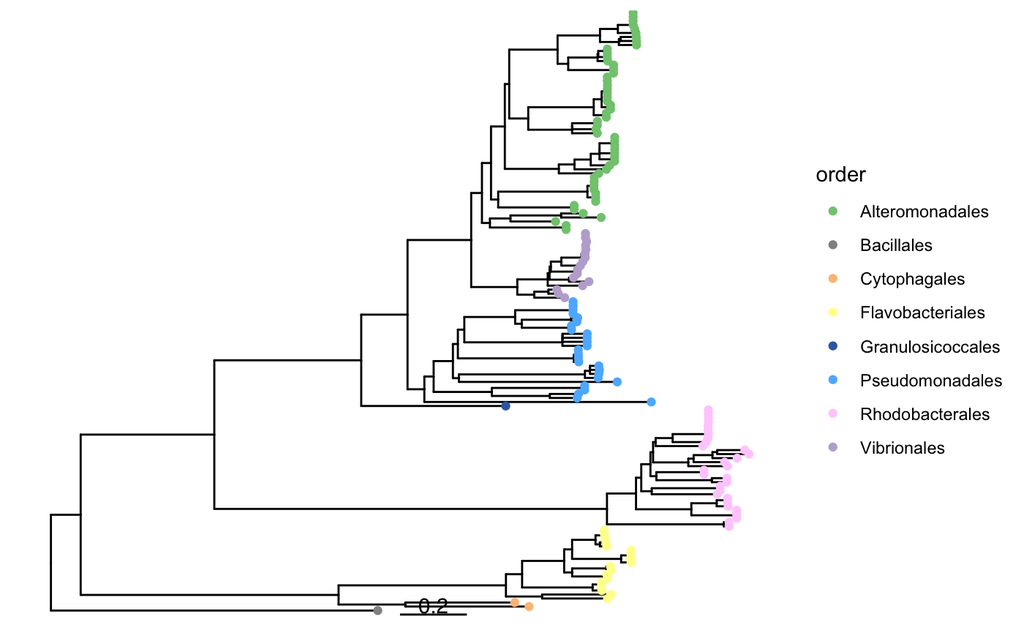

```r
colors <- c("#80C87F","#919191","#FCC086","#FEFE99","#376BB0","#5CB7FF","#FFCFFD","#BEADD4")

p <- ggtree(tree)+geom_treescale()+
  geom_fruit(
          data=phylo,
          geom=geom_point,
          mapping=aes(y=taxa, color=order),
          position="identity"
          )+ scale_color_manual(values=colors)
p
```

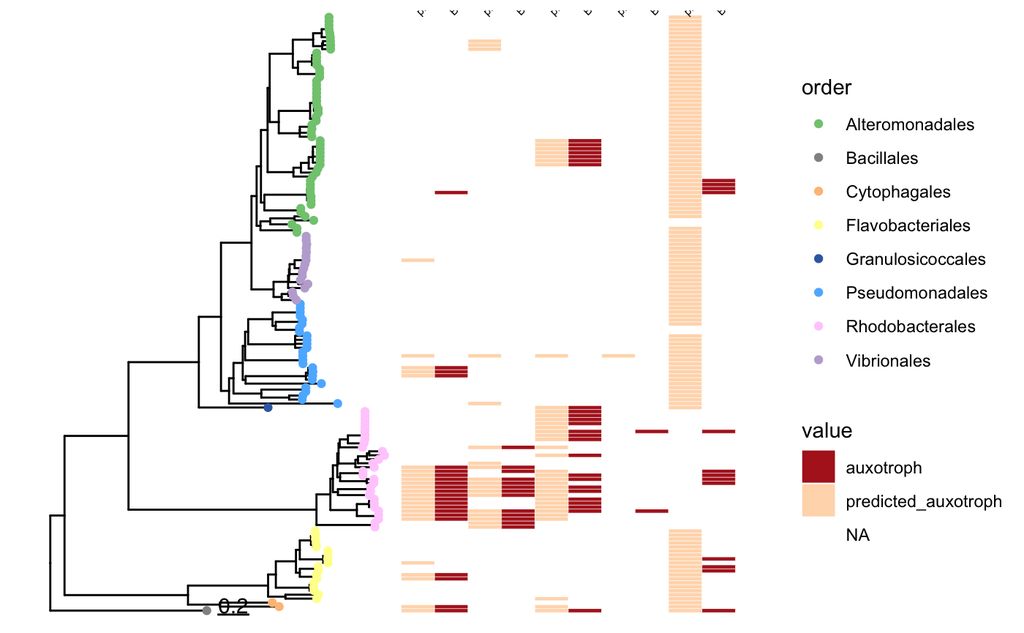

```r
p1 <- p+ new_scale_fill()


##gheatmap.


geno_char <- geno
geno_char[geno_char>0] <-NA
geno_char[geno_char<1] <-"predicted_auxotroph"

pheno_char <- pheno
pheno_char[pheno_char>0] <-NA
pheno_char[pheno_char<1] <-"auxotroph"

pred_char <- cbind(geno_char, pheno_char)

pred_char <- pred_char[,c("predictedB1","B1",
                               "predictedB3","B3",
                               "predictedB7","B7",
                               "predictedB9","B9",
                               "predictedB12","B12")]

p1 <- p+ new_scale_fill()

gheatmap(p1, pred_char, offset=0, width=1, font.size=2,
        colnames_angle=45, hjust=0,
        colnames_position="top", legend_title="Function", colnames_offset_y = 0.1)+
  scale_fill_manual(values=c("firebrick","peachpuff"),na.value="white")
```

Save image

```r
ggsave("figures/predictedvsactual.svg", device= "svg")
```